# H5: Where Does a Surplus Go?

Allocation of the annual surplus across the balance sheet, 2019-2023

# Purpose

H5 from the ratio-correlation memo: **a surplus has to go somewhere**. Every dollar of revenue not spent ends the year as more cash, more receivables, more property, more investments, or less debt. This document estimates that split.

The accounting identity is the check on the estimates. Writing the year’s change in each balance-sheet block as a share of the same denominator, the asset-side coefficients minus the liability-side coefficients must equal the coefficient for the change in net assets, and that in turn should be close to 1 if the surplus is what drives net assets.

Unlike H1-H3, this hypothesis makes no prediction about which component wins. The split itself is the estimate.

**Window.** Pooled tax years 2022 and 2023, December year-ends, organizations that filed a full 990 in every year 2019-2023. Tax years 2020 and 2021 are excluded from the main estimate: relief funding pushed the median surplus margin to 0.113 in 2021 against 0.027 in 2023, and median cash from 5.1 to 7.6 months. 2019 and 2021 are estimated separately as contrasts.

```r
suppressMessages({
  library(data.table)
  library(bit64)
  library(knitr)
})
set.seed(params$seed)
fmt <- function(x, d = 3) formatC(x, format = "f", digits = d)
```

# 1. Data and components

Each block is the end-of-year balance minus the beginning-of-year balance, both from the same filing’s Part X, so the two dates share one accounting basis.

| Block | Part X lines |
| --- | --- |
| Cash | cash + savings |
| Other current assets | pledges, accounts receivable, inventories, prepaid |
| Fixed assets | land, buildings, equipment (net) |
| Other assets | total assets minus the three above (investments, intangibles, notes receivable) |
| Long-term debt | tax-exempt bonds + mortgages + unsecured notes |
| Short-term liabilities | accounts payable + grants payable + deferred revenue |
| Other liabilities | total liabilities minus the two above |

```r
d <- as.data.table(readRDS(params$panel_file))
num <- function(x) { x <- as.numeric(x); x[is.na(x)] <- 0; x }

forms <- d[, .(n990 = sum(RETURN_TYPE == "990"), nez = sum(RETURN_TYPE == "990EZ")), by = EIN2]
stable990 <- forms[n990 >= 5 & nez == 0, EIN2]

x <- d[EIN2 %chin% stable990 & RETURN_TYPE == "990" &
       substr(TAX_PERIOD_END_DATE, 6, 7) == "12"]
rm(d); invisible(gc())

blk <- function(when) {
  s <- function(f) num(x[[paste0(f, "_", when)]])
  data.table(
    cash   = s("F9_10_ASSET_CASH") + s("F9_10_ASSET_SAVING"),
    oca    = s("F9_10_ASSET_PLEDGE_NET") + s("F9_10_ASSET_ACC_NET") +
             s("F9_10_ASSET_INV_SALE") + s("F9_10_ASSET_EXP_PREPAID"),
    fixed  = s("F9_10_ASSET_LAND_BLDG_NET"),
    assets = s("F9_10_ASSET_TOT"),
    lt     = s("F9_10_LIAB_TAX_EXEMPT_BOND") + s("F9_10_LIAB_MTG_NOTE") + s("F9_10_LIAB_NOTE_UNSEC"),
    st     = s("F9_10_LIAB_ACC_PAYABLE") + s("F9_10_LIAB_GRANT_PAYABLE") + s("F9_10_LIAB_REV_DEFERRED"),
    liab   = s("F9_10_LIAB_TOT"),
    na     = s("F9_10_NAFB_TOT"))
}
b <- blk("BOY"); e <- blk("EOY")
b[, `:=`(other_assets = assets - cash - oca - fixed, other_liab = liab - lt - st)]
e[, `:=`(other_assets = assets - cash - oca - fixed, other_liab = liab - lt - st)]

dat <- data.table(
  EIN2 = x$EIN2, year = x$TAX_YEAR,
  E = num(x$F9_09_EXP_TOT_TOT), R = num(x$F9_08_REV_TOT_TOT),
  assets_boy = b$assets,
  # revenue lines (Part VIII) and functional expenses (Part IX), for section 6
  contributions = num(x$F9_08_REV_CONTR_TOT),
  program_revenue = num(x$F9_08_REV_PROG_TOT_TOT),
  investment_income = num(x$F9_08_REV_OTH_INVEST_INCOME_TOT) + num(x$F9_08_REV_OTH_INVEST_BOND_TOT),
  gains_on_sales = num(x$F9_08_REV_OTH_SALE_GAIN_NET_TOT),
  program_expenses = num(x$F9_09_EXP_TOT_PROG),
  admin_expenses = num(x$F9_09_EXP_TOT_MGMT),
  fundraising_expenses = num(x$F9_09_EXP_TOT_FUNDR))
dat[, surplus := R - E]
dat[, other_revenue := R - contributions - program_revenue - investment_income - gains_on_sales]
dat[, unallocated_expenses := E - program_expenses - admin_expenses - fundraising_expenses]
for (v in c("cash", "oca", "fixed", "other_assets", "lt", "st", "other_liab", "assets", "liab", "na")) {
  dat[[paste0("d_", v)]] <- e[[v]] - b[[v]]
}
setnames(dat, "d_oca", "d_other_current")

dat <- dat[E > 0 & assets_boy > 0]
kable(dat[, .(org_years = .N, organizations = uniqueN(EIN2)), by = year][order(year)],
      format.args = list(big.mark = ","))
```

| year | org_years | organizations |
| --- | --- | --- |
| 2,019 | 125,827 | 125,827 |
| 2,020 | 127,091 | 127,091 |
| 2,021 | 127,189 | 127,189 |
| 2,022 | 127,208 | 127,208 |
| 2,023 | 127,184 | 127,184 |
| 2,024 | 112,292 | 112,292 |

# 2. Does the identity hold in the data?

```r
dat[, resid_assets := d_assets - (d_cash + d_other_current + d_fixed + d_other_assets)]
dat[, resid_liab   := d_liab - (d_lt + d_st + d_other_liab)]
dat[, resid_na     := d_na - (d_assets - d_liab)]
kable(dat[, .(
  `assets = sum of blocks` = mean(abs(resid_assets) < 1),
  `liabilities = sum of blocks` = mean(abs(resid_liab) < 1),
  `net assets = assets - liabilities` = mean(abs(resid_na) < 1)), by = year][order(year)],
  digits = 4, caption = "Share of filings where the blocks add up exactly")
```

Share of filings where the blocks add up exactly

| year | assets = sum of blocks | liabilities = sum of blocks | net assets = assets - liabilities |
| --- | --- | --- | --- |
| 2019 | 1 | 1 | 0.9994 |
| 2020 | 1 | 1 | 0.9995 |
| 2021 | 1 | 1 | 0.9996 |
| 2022 | 1 | 1 | 0.9997 |
| 2023 | 1 | 1 | 0.9995 |
| 2024 | 1 | 1 | 0.9990 |

A surplus is not the only thing that moves net assets: unrealized investment gains, prior-period adjustments, and donated capital also land there. The regression below estimates how much of the surplus is traceable, not whether net assets equal the surplus.

# 3. The allocation regressions

Every quantity is divided by the year’s total expenses, so a coefficient reads as “cents of each surplus dollar”.

**Outliers are handled by dropping rows, not by clipping values.** Winsorizing each component separately would break the very identity this test relies on: the clipped parts no longer sum to the clipped total, and the coefficients stop adding up. (A first version of this document did exactly that, and the identity check caught it.) Instead, organization-years outside the 1st/99th percentile of the surplus ratio or of the change in total assets are dropped, within year. Whatever survives keeps its raw values, so the blocks still add up and OLS coefficients add up with them.

Standard errors are HC1. Each row is one organization-year, and the pooled window holds two years per organization, so the robustness section repeats the estimate with organization fixed effects.

```r
SCALED <- c("surplus", "d_cash", "d_other_current", "d_fixed", "d_other_assets",
            "d_lt", "d_st", "d_other_liab", "d_assets", "d_liab", "d_na",
            "contributions", "program_revenue", "investment_income", "gains_on_sales",
            "other_revenue", "program_expenses", "admin_expenses", "fundraising_expenses",
            "unallocated_expenses")

scale_vars <- function(z, trim = TRUE) {
  out <- copy(z)
  for (v in SCALED) out[[v]] <- out[[v]] / out$E
  if (!trim) return(out)
  # `:=` by group assigns back to the right rows; a grouped select would return
  # the flags in group order and misalign them when years are interleaved.
  out[, keep := {
    qs <- quantile(surplus, c(0.01, 0.99), na.rm = TRUE)
    qa <- quantile(d_assets, c(0.01, 0.99), na.rm = TRUE)
    surplus >= qs[[1]] & surplus <= qs[[2]] & d_assets >= qa[[1]] & d_assets <= qa[[2]]
  }, by = year]
  out <- out[keep == TRUE]
  out[, keep := NULL]
  out[]
}

ols <- function(y, W) {
  XtXi <- solve(crossprod(W))
  bhat <- drop(XtXi %*% crossprod(W, y))
  res <- drop(y - W %*% bhat)
  V <- XtXi %*% crossprod(W * res) %*% XtXi * nrow(W) / (nrow(W) - ncol(W))
  list(b = bhat, se = sqrt(diag(V)))
}

BLOCKS <- c(cash = "d_cash", other_current_assets = "d_other_current", fixed_assets = "d_fixed",
            other_assets = "d_other_assets", long_term_debt = "d_lt",
            short_term_liabilities = "d_st", other_liabilities = "d_other_liab")

allocate <- function(z, label, trim = TRUE) {
  s <- scale_vars(z, trim = trim)
  W <- cbind(intercept = 1, surplus = s$surplus)
  out <- rbindlist(lapply(names(BLOCKS), function(nm) {
    f <- ols(s[[BLOCKS[[nm]]]], W)
    data.table(window = label, block = nm, cents_per_surplus_dollar = f$b[["surplus"]],
               se = f$se[["surplus"]])
  }))
  side <- c(cash = 1, other_current_assets = 1, fixed_assets = 1, other_assets = 1,
            long_term_debt = -1, short_term_liabilities = -1, other_liabilities = -1)
  out[, side := ifelse(side[block] > 0, "asset", "liability")]
  attr(out, "identity") <- data.table(
    window = label,
    assets_minus_liabilities = sum(out$cents_per_surplus_dollar * side[out$block]),
    net_assets_direct = ols(s$d_na, W)$b[["surplus"]],
    n = nrow(s))
  out
}

main <- allocate(dat[year %in% 2022:2023], "2022-2023")
kable(main[, .(block, side, cents_per_surplus_dollar = round(cents_per_surplus_dollar, 3),
               se = round(se, 4))],
      caption = "Where each dollar of surplus lands, 2022-2023")
```

Where each dollar of surplus lands, 2022-2023

| block | side | cents_per_surplus_dollar | se |
| --- | --- | --- | --- |
| cash | asset | 0.371 | 0.0273 |
| other_current_assets | asset | 0.037 | 0.0046 |
| fixed_assets | asset | 0.139 | 0.0147 |
| other_assets | asset | 0.320 | 0.0309 |
| long_term_debt | liability | -0.021 | 0.0030 |
| short_term_liabilities | liability | -0.010 | 0.0017 |
| other_liabilities | liability | -0.087 | 0.0693 |

```r
kable(attr(main, "identity"), digits = 3,
      caption = "Identity check: asset coefficients minus liability coefficients vs. the direct net-assets regression")
```

Identity check: asset coefficients minus liability coefficients vs. the direct net-assets regression

| window | assets_minus_liabilities | net_assets_direct | n |
| --- | --- | --- | --- |
| 2022-2023 | 0.985 | 0.985 | 247124 |

```r
untrimmed <- allocate(dat[year %in% 2022:2023], "2022-2023, no trimming", trim = FALSE)
kable(merge(main[, .(block, trimmed = cents_per_surplus_dollar)],
            untrimmed[, .(block, untrimmed = cents_per_surplus_dollar)], by = "block"),
      digits = 3, caption = "Trimmed vs. untrimmed")
```

Trimmed vs. untrimmed

| block | trimmed | untrimmed |
| --- | --- | --- |
| cash | 0.371 | 0.969 |
| fixed_assets | 0.139 | 0.000 |
| long_term_debt | -0.021 | 0.000 |
| other_assets | 0.320 | 0.019 |
| other_current_assets | 0.037 | 0.014 |
| other_liabilities | -0.087 | -0.001 |
| short_term_liabilities | -0.010 | 0.000 |

```r
kable(rbind(attr(main, "identity"), attr(untrimmed, "identity")), digits = 3,
      caption = "Identity check, both samples")
```

Identity check, both samples

| window | assets_minus_liabilities | net_assets_direct | n |
| --- | --- | --- | --- |
| 2022-2023 | 0.985 | 0.985 | 247124 |
| 2022-2023, no trimming | 1.003 | 1.003 | 254392 |

# 4. Contrasts and robustness

```r
windows <- list(`2019 (pre-COVID)` = dat[year == 2019],
                `2021 (relief year)` = dat[year == 2021],
                `2022` = dat[year == 2022], `2023` = dat[year == 2023])
contrasts <- rbindlist(lapply(names(windows), function(nm) allocate(windows[[nm]], nm)))
kable(dcast(rbind(contrasts, main), block + side ~ window, value.var = "cents_per_surplus_dollar"),
      digits = 3, caption = "Allocation by year")
```

Allocation by year

| block | side | 2019 (pre-COVID) | 2021 (relief year) | 2022 | 2022-2023 | 2023 |
| --- | --- | --- | --- | --- | --- | --- |
| cash | asset | 0.342 | 0.390 | 0.380 | 0.371 | 0.361 |
| fixed_assets | asset | 0.214 | 0.100 | 0.128 | 0.139 | 0.151 |
| long_term_debt | liability | -0.012 | -0.011 | -0.031 | -0.021 | -0.011 |
| other_assets | asset | 0.525 | 0.495 | 0.165 | 0.320 | 0.479 |
| other_current_assets | asset | 0.024 | 0.033 | 0.032 | 0.037 | 0.043 |
| other_liabilities | liability | -0.008 | -0.013 | -0.026 | -0.087 | -0.150 |
| short_term_liabilities | liability | -0.002 | 0.000 | -0.011 | -0.010 | -0.008 |

```r
ident <- rbindlist(lapply(c(list(main), lapply(names(windows), function(nm) allocate(windows[[nm]], nm))),
                          function(z) attr(z, "identity")))
kable(ident, digits = 3, caption = "Identity check by window")
```

Identity check by window

| window | assets_minus_liabilities | net_assets_direct | n |
| --- | --- | --- | --- |
| 2022-2023 | 0.985 | 0.985 | 247124 |
| 2019 (pre-COVID) | 1.126 | 1.126 | 122061 |
| 2021 (relief year) | 1.042 | 1.042 | 123406 |
| 2022 | 0.774 | 0.774 | 123822 |
| 2023 | 1.202 | 1.202 | 123302 |

**Surpluses versus deficits.** A deficit has to be funded from the same blocks. Splitting the predictor at zero asks whether the two are mirror images.

```r
s <- scale_vars(dat[year %in% 2022:2023])
s[, `:=`(surplus_pos = pmax(surplus, 0), surplus_neg = pmin(surplus, 0))]
W <- cbind(intercept = 1, surplus_pos = s$surplus_pos, surplus_neg = s$surplus_neg)
asym <- rbindlist(lapply(names(BLOCKS), function(nm) {
  f <- ols(s[[BLOCKS[[nm]]]], W)
  data.table(block = nm, surplus_cents = f$b[["surplus_pos"]], surplus_se = f$se[["surplus_pos"]],
             deficit_cents = f$b[["surplus_neg"]], deficit_se = f$se[["surplus_neg"]])
}))
kable(asym, digits = 3, caption = "Allocation of surpluses vs. funding of deficits, 2022-2023")
```

Allocation of surpluses vs. funding of deficits, 2022-2023

| block | surplus_cents | surplus_se | deficit_cents | deficit_se |
| --- | --- | --- | --- | --- |
| cash | 0.342 | 0.032 | 0.575 | 0.055 |
| other_current_assets | 0.034 | 0.005 | 0.060 | 0.007 |
| fixed_assets | 0.146 | 0.018 | 0.089 | 0.012 |
| other_assets | 0.327 | 0.036 | 0.273 | 0.056 |
| long_term_debt | -0.025 | 0.004 | 0.005 | 0.005 |
| short_term_liabilities | -0.009 | 0.002 | -0.010 | 0.004 |
| other_liabilities | -0.102 | 0.084 | 0.020 | 0.035 |

```r
cat("share of organization-years with a deficit:",
    fmt(mean(dat[year %in% 2022:2023, surplus < 0]), 3), "\n")
```

```
## share of organization-years with a deficit: 0.421
```

**Organization fixed effects.** The pooled estimate mixes differences between organizations with differences within one organization across years. Demeaning by organization over 2019, 2022, and 2023 keeps only the within variation.

```r
fe_dat <- scale_vars(dat[year %in% c(2019, 2022, 2023)])
demean <- function(v, g) v - ave(v, g, FUN = mean)
g <- fe_dat$EIN2
W <- cbind(surplus = demean(fe_dat$surplus, g))
fe <- rbindlist(lapply(names(BLOCKS), function(nm) {
  f <- ols(demean(fe_dat[[BLOCKS[[nm]]]], g), W)
  data.table(block = nm, within_org_cents = f$b[["surplus"]], se = f$se[["surplus"]])
}))
kable(merge(fe, main[, .(block, pooled_cents = cents_per_surplus_dollar)], by = "block"),
      digits = 3, caption = "Within-organization vs. pooled allocation")
```

Within-organization vs. pooled allocation

| block | within_org_cents | se | pooled_cents |
| --- | --- | --- | --- |
| cash | 0.434 | 0.015 | 0.371 |
| fixed_assets | 0.154 | 0.011 | 0.139 |
| long_term_debt | -0.018 | 0.002 | -0.021 |
| other_assets | 0.321 | 0.018 | 0.320 |
| other_current_assets | 0.046 | 0.004 | 0.037 |
| other_liabilities | -0.081 | 0.048 | -0.087 |
| short_term_liabilities | -0.011 | 0.001 | -0.010 |

# 5. Where the surplus comes from

The allocation above answers where a surplus goes. The same sample answers where it comes from, in the same units. Because the surplus is revenue minus expenses, and both are sums of reported lines, the covariance of each line with the surplus, divided by the variance of the surplus, gives shares that add to exactly 1. A share of 0.64 for contributions means that of a one-dollar difference in surplus, 64 cents co-move with contributions.

```r
si <- scale_vars(dat[year %in% 2022:2023])
vs <- var(si$surplus)
share <- function(v, sign = 1) sign * cov(si[[v]], si$surplus) / vs
inflow <- c(contributions = share("contributions"), program_revenue = share("program_revenue"),
            investment_income = share("investment_income"), gains_on_sales = share("gains_on_sales"),
            other_revenue = share("other_revenue"),
            program_expenses = share("program_expenses", -1),
            admin_expenses = share("admin_expenses", -1),
            fundraising_expenses = share("fundraising_expenses", -1),
            unallocated_expenses = share("unallocated_expenses", -1))
kable(data.frame(line = names(inflow), side = c(rep("revenue", 5), rep("expense", 4)),
                 share_of_surplus_variation = round(inflow, 3), row.names = NULL),
      caption = "Shares add to 1 by construction")
```

Shares add to 1 by construction

| line | side | share_of_surplus_variation |
| --- | --- | --- |
| contributions | revenue | 0.641 |
| program_revenue | revenue | 0.062 |
| investment_income | revenue | 0.112 |
| gains_on_sales | revenue | 0.086 |
| other_revenue | revenue | 0.099 |
| program_expenses | expense | 0.008 |
| admin_expenses | expense | -0.014 |
| fundraising_expenses | expense | -0.005 |
| unallocated_expenses | expense | 0.011 |

```r
cat("revenue lines:", fmt(sum(inflow[1:5])), " expense lines:", fmt(sum(inflow[6:9])),
    " total:", fmt(sum(inflow)), "\n")
```

```
## revenue lines: 1.000  expense lines: 0.000  total: 1.000
```

Surpluses are revenue events. The five revenue lines account for the whole of the variation, and the four expense lines net to about zero: organizations with unusually good years are not the ones that spent unusually little.

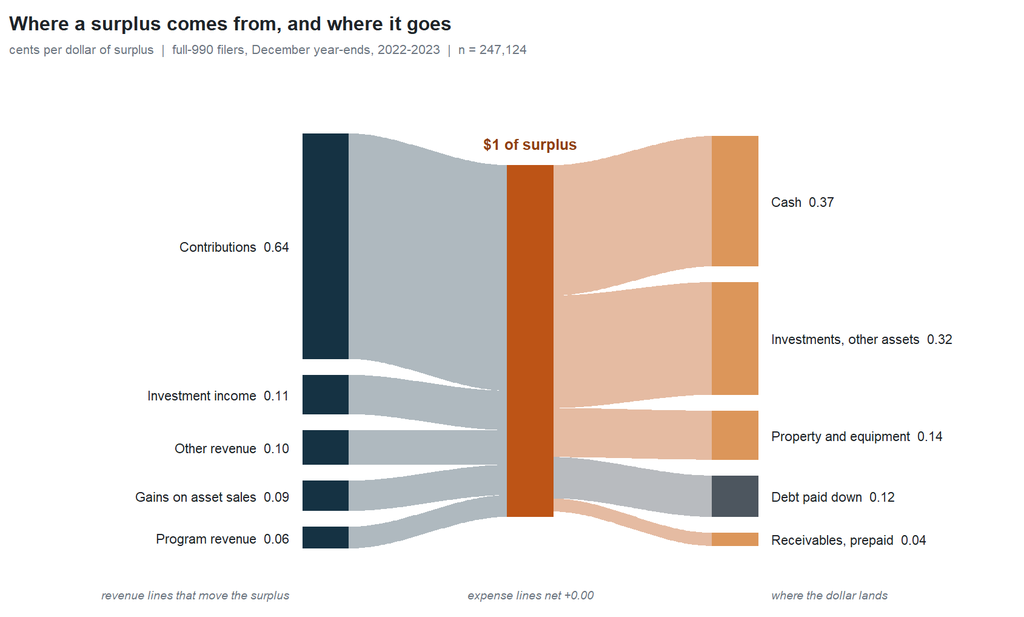

```r
pal <- c(ink = "#1f2429", ink_mid = "#4d565f", ink_soft = "#6d7681",
         accent = "#bd5416", accent_ink = "#8f3f10", navy = "#153243", pumpkin = "#dc965a")
a <- setNames(main$cents_per_surplus_dollar, main$block)
sources <- c(Contributions = inflow[["contributions"]],
             `Investment income` = inflow[["investment_income"]],
             `Other revenue` = inflow[["other_revenue"]],
             `Gains on asset sales` = inflow[["gains_on_sales"]],
             `Program revenue` = inflow[["program_revenue"]])
uses <- c(Cash = a[["cash"]], `Investments, other assets` = a[["other_assets"]],
          `Property and equipment` = a[["fixed_assets"]],
          `Debt paid down` = -(a[["long_term_debt"]] + a[["short_term_liabilities"]] +
                               a[["other_liabilities"]]),
          `Receivables, prepaid` = a[["other_current_assets"]])

flow_figure <- function(sources, uses, expense_net, subtitle) {
  op <- par(mar = c(0.4, 0.4, 2.6, 0.4), bg = "white", family = "sans")
  on.exit(par(op))
  plot.new(); plot.window(xlim = c(0, 1), ylim = c(-0.14, 1.30))
  gap <- 0.045; centre <- 0.56
  stack <- function(v) {
    y <- centre + (sum(v) + gap * (length(v) - 1)) / 2
    out <- lapply(v, function(h) { r <- c(top = y, bot = y - h); y <<- y - h - gap; r })
    names(out) <- names(v); out
  }
  ribbon <- function(x0, x1, t0, b0, t1, b1, col, alpha) {
    t <- seq(0, 1, length.out = 80); s <- t * t * (3 - 2 * t); xs <- x0 + (x1 - x0) * t
    polygon(c(xs, rev(xs)), c(t0 + (t1 - t0) * s, rev(b0 + (b1 - b0) * s)),
            col = adjustcolor(col, alpha), border = NA)
  }
  xs <- c(0.275, 0.325); xt <- c(0.495, 0.545); xu <- c(0.715, 0.765)
  src <- stack(sources); use <- stack(uses)
  top <- centre + 0.5
  cur <- top
  for (i in seq_along(src)) {
    ribbon(xs[2], xt[1], src[[i]][["top"]], src[[i]][["bot"]], cur, cur - sources[[i]],
           pal[["navy"]], 0.34); cur <- cur - sources[[i]]
  }
  cur <- top
  for (i in seq_along(use)) {
    ribbon(xt[2], xu[1], cur, cur - uses[[i]], use[[i]][["top"]], use[[i]][["bot"]],
           if (names(uses)[i] == "Debt paid down") pal[["ink_mid"]] else pal[["accent"]], 0.40)
    cur <- cur - uses[[i]]
  }
  for (i in seq_along(src)) {
    rect(xs[1], src[[i]][["bot"]], xs[2], src[[i]][["top"]], col = pal[["navy"]], border = NA)
    text(xs[1] - 0.014, mean(src[[i]]), sprintf("%s  %.2f", names(sources)[i], sources[[i]]),
         adj = c(1, 0.5), cex = 0.68, col = pal[["ink"]])
  }
  rect(xt[1], centre - 0.5, xt[2], top, col = pal[["accent"]], border = NA)
  text(mean(xt), top + 0.045, "$1 of surplus", adj = c(0.5, 0), cex = 0.78, font = 2,
       col = pal[["accent_ink"]])
  for (i in seq_along(use)) {
    rect(xu[1], use[[i]][["bot"]], xu[2], use[[i]][["top"]],
         col = if (names(uses)[i] == "Debt paid down") pal[["ink_mid"]] else pal[["pumpkin"]],
         border = NA)
    text(xu[2] + 0.014, mean(use[[i]]), sprintf("%s  %.2f", names(uses)[i], uses[[i]]),
         adj = c(0, 0.5), cex = 0.68, col = pal[["ink"]])
  }
  text(xs[1] - 0.014, centre - 0.72, "revenue lines that move the surplus", adj = c(1, 0.5),
       cex = 0.6, col = pal[["ink_soft"]], font = 3)
  text(mean(xt), centre - 0.72, sprintf("expense lines net %+.2f", expense_net),
       adj = c(0.5, 0.5), cex = 0.6, col = pal[["ink_soft"]], font = 3)
  text(xu[2] + 0.014, centre - 0.72, "where the dollar lands", adj = c(0, 0.5),
       cex = 0.6, col = pal[["ink_soft"]], font = 3)
  mtext("Where a surplus comes from, and where it goes", side = 3, line = 1.1, adj = 0,
        cex = 1.0, font = 2, col = pal[["ink"]])
  mtext(subtitle, side = 3, line = 0.1, adj = 0, cex = 0.66, col = pal[["ink_soft"]])
}

flow_figure(sources, uses, sum(inflow[6:9]),
            paste0("cents per dollar of surplus  |  full-990 filers, December year-ends, 2022-2023  |  n = ",
                   format(nrow(si), big.mark = ",")))
```

The two sides are not symmetric. Surpluses arrive mostly as contributions and investment returns, and they leave mostly as cash and investments. Property absorbs a seventh, and debt repayment a smaller share still.

# 6. Findings

- **Traceable share.** The asset-side minus liability-side coefficients sum to 0.985, against 0.985 from regressing the change in net assets directly on the surplus. The identity holds in the estimates.
- **Cash.** 0.371 of each surplus dollar ends the year as cash.
- **Property.** 0.139 goes into land, buildings, and equipment.
- **Other assets.** 0.320, mostly investments.
- **Debt.** Long-term debt changes by -0.021 and short-term liabilities by -0.010 per surplus dollar; negative coefficients mean surpluses coincide with paying debt down.